© Bản quyền thuộc về Quantopian Inc.  
© Bản quyền sửa đổi thuộc về AI Cafe¹  
Giấy phép [Creative Commons Attribution 4.0](https://creativecommons.org/licenses/by/4.0/legalcode).  
[Khuyến cáo](https://aicafe.one/khuyen-cao/)

# Nhân tố tiếp xúc rủi ro

By Evgenia "Jenny" Nitishinskaya, Delaney Granizo-Mackenzie, and Maxwell Margenot.

Edited by AI Cafe¹

## CẢNH BÁO

Như thường lệ, phân tích này dựa trên dữ liệu lịch sử, và các rủi ro ước tính dựa trên dữ liệu lịch sử có thể hoặc không thể ảnh hưởng đến các rủi ro trong tương lai. Do đó, việc tính toán rủi ro của một yếu tố là không đủ. Bạn phải đặt ra các giới hạn tin cậy cho rủi ro đó, và xác định liệu rủi ro đó có thể được mô hình hóa một cách hợp lý hay không. Để biết thêm thông tin về điều này, vui lòng xem các bài giảng khác của chúng tôi, đặc biệt là bài Sự Không Ổn Định của Các Ước Tính Tham Số.

## Sử Dụng Mô Hình Yếu Tố Để Xác Định Rủi Ro

Chúng ta có thể sử dụng mô hình yếu tố để phân tích các nguồn rủi ro và lợi nhuận trong danh mục đầu tư. Nhớ rằng một mô hình yếu tố biểu thị lợi nhuận như sau:

$$R_i = a_i + b_{i1} F_1 + b_{i2} F_2 + \ldots + b_{iK} F_K + \epsilon_i$$

Bằng cách mô hình hóa các lợi nhuận lịch sử, chúng ta có thể thấy bao nhiêu trong số đó là do đầu cơ vào các yếu tố khác nhau và bao nhiêu là do sự biến động riêng của tài sản ($\epsilon_p$). Chúng ta cũng có thể xem xét những nguồn rủi ro mà danh mục đầu tư đang phải đối mặt.

Trong phân tích rủi ro, chúng ta thường mô hình hóa lợi nhuận chủ động (lợi nhuận so với một chỉ số tham chiếu) và rủi ro chủ động (độ lệch chuẩn của lợi nhuận chủ động, còn được gọi là sai số theo dõi hoặc rủi ro theo dõi).

Ví dụ, chúng ta có thể tìm đóng góp biên của một yếu tố đối với rủi ro chủ động bình phương (FMCAR). Đối với yếu tố $j$, điều này là:

$$ \text{FMCAR}_j = \frac{b_j^a \sum_{i=1}^K b_i^a Cov(F_j, F_i)}{(\text{Rủi ro chủ động})^2} $$

Trong đó $b_i^a$ là mức độ tiếp xúc chủ động của danh mục đầu tư với yếu tố $i$. Điều này cho chúng ta biết mức độ rủi ro mà chúng ta phải chịu khi tiếp xúc với yếu tố $j$, dựa trên tất cả các yếu tố khác mà chúng ta đã tiếp xúc.

Chúng ta sẽ sử dụng các yếu tố Fama-French chuẩn cho ví dụ này, đó là lợi nhuận của các danh mục đầu tư được xây dựng dựa trên các yếu tố cơ bản.

## Bạn muốn bao nhiêu yếu tố?

Trong bài giảng về Lý thuyết định giá chênh lệch, chúng ta đề cập rằng đối với các mô hình dự đoán, bạn muốn có ít tham số hơn. Tuy nhiên, điều này không hoàn toàn đúng đối với rủi ro. Thay vì cố gắng không làm quá khớp một mô hình dự đoán, bạn đang tìm kiếm bất kỳ yếu tố rủi ro nào có thể ảnh hưởng đến lợi nhuận của bạn. Do đó, thực tế là an toàn hơn khi ước lượng mức độ tiếp xúc với nhiều yếu tố rủi ro để xem liệu có bất kỳ yếu tố nào hiệu quả. Bất kỳ điều gì còn lại trong $\alpha$ của chúng ta là mức độ tiếp xúc với rủi ro hiện không được giải thích bởi các yếu tố đã chọn. Bạn muốn dòng lợi nhuận của chiến lược của mình hoàn toàn là alpha, và không được giải thích bởi càng nhiều tham số càng tốt. Nếu bạn có thể chỉ ra rằng lợi nhuận lịch sử của bạn ít hoặc không phụ thuộc vào nhiều yếu tố, điều này rất tích cực. Chắc chắn rằng một số yếu tố rủi ro không liên quan có thể có mối quan hệ giả tạo theo thời gian trong một tập dữ liệu lớn, nhưng những điều đó không có khả năng nhất quán.

## Thiết lập

Điều đầu tiên chúng ta cần làm là tính toán lợi suất của các yếu tố trong suốt một năm.

*Chú ý: dữ liệu cơ bản được lấy từ CSDL của AI Cafe¹, chúng tôi không public dữ liệu này, khi chạy lại notebook các bạn có thể bỏ qua những cell dưới đây*

```python
!curl -fsSLO https://raw.githubusercontent.com/algo-stocks/data/master/data/robusta.py
%run -i robusta.py
```

Chúng ta import các thư viện

```python
import pandas as pd
import numpy as np
import matplotlib.pyplot as plt
from statsmodels import regression

from data import universe, get_prices, fin_std, get_fin_stmt, fin_stmt_date_idx, date_reindex
```

Và lấy dữ liệu cần thiết cho bài giảng này:

```python
tickers = np.array(universe('VN100')[:'2023'].iloc[-1].dropna().index)

start_date, end_date = '2024-01-01', '2024-12-31'

# Prices Data
prices = get_prices(*tickers, start_date='2023-12-01', end_date=end_date, field=['close', 'share', 'unadjusted'])
market_caps = 1000 * prices.xs('unadjusted', axis=1, level=1) * prices.xs('share', axis=1, level=1)
closes = prices.xs('close', axis=1, level=1).ffill()
returns = closes.pct_change(fill_method=None)[start_date:]

# Fundamental Data
book_value = fin_std({'_': 302, 'bs26857059': '309+308', 'bs7037699336': 4, 'bs1683709501': '302+303'})
BOOK = pd.DataFrame()
for ticker in tickers:
  bsq = get_fin_stmt(ticker, 'bsq', True)
  bsd = fin_stmt_date_idx(bsq)
  bv = book_value(bsd)
  bv = bv[~bv.index.duplicated(keep='last')]
  BOOK = BOOK.join(bv.to_frame(ticker), how='outer')

book_to_price = date_reindex(BOOK, market_caps.index) / market_caps

# Size
cap_rank = market_caps.rank(axis=1, ascending=False)
R_biggest = returns[cap_rank < 31].mean(axis=1)
R_smallest = returns[cap_rank > 70].mean(axis=1)

# Value
value_rank = book_to_price.rank(axis=1, ascending=False)
R_highpb = returns[value_rank < 31].mean(axis=1)
R_lowpb = returns[value_rank > 70].mean(axis=1)

# Benchmark
M = get_prices('VN100', frequency='index', end_date=end_date).VN100.pct_change()[start_date:]

# Defining our final factors
SMB = R_smallest - R_biggest # small minus big
HML = R_highpb - R_lowpb # high minus low
```

Cùng xem các yếu tố hiệu quả ra sao trong năm 2024?

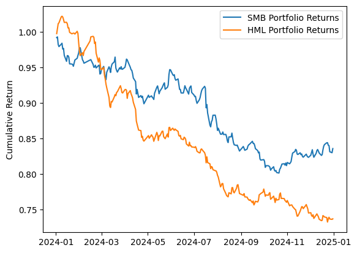

```python
SMB_CUM = np.cumprod(SMB+1)
HML_CUM = np.cumprod(HML+1)

plt.plot(SMB_CUM.index, SMB_CUM.values)
plt.plot(HML_CUM.index, HML_CUM.values)
plt.ylabel('Cumulative Return')
plt.legend(['SMB Portfolio Returns', 'HML Portfolio Returns']);
```

## Tính Toán Mức Độ Tiếp Xúc Rủi Ro

```python
portfolio = get_prices('FPT', 'VCB', 'BID', end_date=end_date).pct_change()[start_date:]
R = portfolio.mean(axis=1)

# The excess returns of our active management, in this case just holding a portfolio of our one asset
active = R - M

# Define a constant to compute intercept
constant = pd.Series(np.ones(len(active.index)), index=active.index)

df = pd.DataFrame({'R': active,
              'F1': SMB,
              'F2': HML,
              'Constant': constant}).dropna()
```

```python
# Perform linear regression to get the coefficients in the model
b1, b2 = regression.linear_model.OLS(df['R'], df[['F1', 'F2']]).fit().params

# Print the coefficients from the linear regression
print('Sensitivities of active returns to factors:\nSMB: %f\nHML: %f' %  (b1, b2))
```

```
Sensitivities of active returns to factors:
SMB: -0.133414
HML: -0.348804
```

Sử dụng công thức từ đầu bài giảng, chúng ta có thể tính toán đóng góp biên của các yếu tố vào rủi ro chủ động bình phương.

```python
F1 = df['F1']
F2 = df['F2']
cov = np.cov(F1, F2)
ar_squared = (active.std())**2
fmcar1 = (b1*(b2*cov[0,1] + b1*cov[0,0]))/ar_squared
fmcar2 = (b2*(b1*cov[0,1] + b2*cov[1,1]))/ar_squared
print('SMB Risk Contribution:', fmcar1)
print('HML Risk Contribution:', fmcar2)
```

```
SMB Risk Contribution: 0.03026444198645588
HML Risk Contribution: 0.11613773044131927
```

Phần còn lại của rủi ro có thể được quy cho rủi ro cụ thể chủ động, tức là các yếu tố mà chúng ta đã không tính đến hoặc rủi ro riêng biệt của tài sản.

## Danh mục yếu tố và theo dõi

Chúng ta có thể sử dụng danh mục yếu tố và danh mục theo dõi để điều chỉnh độ nhạy của một danh mục đầu tư đối với các nguồn rủi ro khác nhau.

Một *danh mục yếu tố* có độ nhạy là 1 đối với một yếu tố cụ thể và 0 đối với tất cả các yếu tố khác. Nói cách khác, nó đại diện cho rủi ro của yếu tố đó. Chúng ta có thể thêm một danh mục yếu tố vào một danh mục lớn hơn để điều chỉnh mức độ tiếp xúc của nó với yếu tố đó.

Một khái niệm tương tự là *danh mục theo dõi*, được xây dựng để có cùng độ nhạy yếu tố như một chỉ số tham chiếu hoặc danh mục khác. Giống như danh mục yếu tố, điều này cho phép chúng ta đầu cơ hoặc phòng ngừa rủi ro liên quan đến chỉ số tham chiếu hoặc danh mục đó. Ví dụ, chúng ta thường xuyên phòng ngừa rủi ro thị trường, vì chúng ta quan tâm đến việc danh mục đầu tư của mình hoạt động như thế nào so với thị trường, và chúng ta không muốn bị ảnh hưởng bởi sự biến động của thị trường.

Để xây dựng một danh mục yếu tố hoặc danh mục theo dõi, chúng ta cần độ nhạy yếu tố của những gì chúng ta muốn theo dõi. Chúng ta đã biết những điều này trong trường hợp trước, nhưng chúng ta cần tính toán chúng trong trường hợp sau bằng các phương pháp mô hình yếu tố thông thường. Sau đó, chúng ta chọn một số tài sản $K+1$ (nơi $K$ là số lượng yếu tố mà chúng ta đang xem xét) và tính trọng số của các tài sản trong danh mục.

## Độ nhạy danh mục đầu tư

Độ nhạy của danh mục đầu tư có thể được tính trực tiếp từ dòng lợi nhuận, hoặc như là trung bình trọng số của tất cả các tài sản đang nắm giữ.

## Ví dụ

Giả sử chúng ta có hai yếu tố $F_1$ và $F_2$, và một chỉ số tham chiếu với độ nhạy lần lượt là 1 và 1.1 đối với các yếu tố này. Chúng ta xác định 3 chứng khoán $x_1, x_2, x_3$ mà chúng ta muốn sử dụng để tạo thành một danh mục đầu tư theo dõi chỉ số tham chiếu, có độ nhạy là $b_{11} = 0.7$, $b_{12} = 1.1$, $b_{21} = 0.1$, $b_{22} = 0.5$, $b_{31} = 1.5$, $b_{32} = 1.3$. Chúng ta muốn tính toán các trọng số $w_1$, $w_2$, $w_3$ sao cho danh mục đầu tư theo dõi của chúng ta là

$$ P = w_1 x_1 + w_2 x_2 + w_3 x_3 $$

Chúng ta muốn độ nhạy của danh mục đầu tư khớp với chỉ số tham chiếu:

$$ w_1 b_{11} + w_2 b_{21} + w_3 b_{31} = 1 $$ $$ w_1 b_{12} + w_2 b_{22} + w_3 b_{32} = 1.1 $$

Ngoài ra, các trọng số cần phải tổng bằng 1:

$$ w_1 + w_2 + w_3 = 1 $$

Giải hệ phương trình tuyến tính này, chúng ta tìm được rằng $w_1 = 1/3$, $w_2 = 1/6$, và $w_3 = 1/2$. Ghép các chứng khoán lại thành một danh mục đầu tư sử dụng các trọng số này, chúng ta có được một danh mục đầu tư có cùng hồ sơ rủi ro với chỉ số tham chiếu.

## Cách Sử Dụng Mô Hình Rủi Ro

Khi chúng ta đã biết được các rủi ro mà mình đang đối mặt, chúng ta có thể thực hiện một số hành động. Chúng ta có thể không tham gia vào các vị thế có mức độ nhạy cảm cao với một số yếu tố nhất định, hoặc chúng ta có thể tiến hành phòng vệ cho các vị thế của mình nhằm cố gắng trung hòa mức độ nhạy cảm đó.

### Quản Lý Rủi Ro

Thường thì các quỹ sẽ có một lớp bảo vệ cho các nhà giao dịch/thuật toán của họ. Lớp bảo vệ này sẽ tiếp nhận các giao dịch mà quỹ muốn thực hiện, sau đó tính toán mức độ nhạy cảm của danh mục mới và kiểm tra xem chúng có nằm trong các phạm vi đã được xác định trước hay không. Nếu không, nó sẽ không thực hiện giao dịch và đưa ra cảnh báo.

### Phòng vệ

Một phương pháp khác để xử lý mức độ nhạy cảm là thực hiện các phòng vệ. Bạn có thể xác định, chẳng hạn, mức độ nhạy cảm của mình với từng lĩnh vực của thị trường. Sau đó, bạn có thể thực hiện hợp đồng phòng vệ nếu một lĩnh vực cụ thể dường như ảnh hưởng quá nhiều đến lợi nhuận của bạn. Để biết thêm thông tin về phòng vệ, xin vui lòng xem bài giảng về Phòng vệ Beta của chúng tôi. Các thuật toán tốt sẽ có logic phòng vệ tích hợp sẵn để đảm bảo rằng chúng không bao giờ bị quá nhạy cảm.

*Lưu ý: Tài liệu này mang tính chất chia sẻ kiến thức khoa học dữ liệu. Các mã chứng khoán xuất hiện trong tài liệu chỉ mang tính chất minh hoạ, không khuyến nghị đầu tư. Chúng tôi không chịu trách nhiệm trước mọi rủi ro nào do sử dụng tài liệu này.*